# annotate_cpes

Humbert Costas

Sys.Date()

```r
# root path
if (!dir.exists(p_data_path))
  dir.create(p_data_path)

# version subpath
name_folder <- file.path(p_data_path, paste0("v", p_version))
if (!dir.exists(name_folder))
  dir.create(name_folder)

# seed subpath
name_folder <- file.path(p_data_path, paste0("v", p_version), p_seed)
if (!dir.exists(name_folder))
  dir.create(name_folder)
```

## Annotate CPE standard

```r
if (p_kind %in% c("all", "RASA")) {
  # Load CPEs annotated with RASA
  if (file.exists(file.path(name_folder, paste0("cpes_", p_type,"_rasa.rds")))) {
    df_rasa <- readRDS(file.path(name_folder, paste0("cpes_", p_type,"_rasa.rds")))
  } else {
    df_rasa <- mitre::nlp_cpe_annotate(type = p_type, kind = "RASA")
    saveRDS(df_rasa, file.path(name_folder, paste0("cpes_", p_type,"_rasa.rds")))
  }
  readr::write_csv(x = df_rasa,
                   file = file.path(name_folder,paste0("cpes_", p_type,"_rasa.csv")),
                   col_names = FALSE)
}

if (p_kind %in% c("all", "entities")) {
  # Load CPEs annotated with ENTITIES
  if (file.exists(file.path(name_folder, paste0("cpes_", p_type,"_entities.rds")))) {
    df_enti <- readRDS(file.path(name_folder, paste0("cpes_", p_type,"_entities.rds")))
  } else {
    df_enti <- mitre::nlp_cpe_annotate(type = p_type, kind = "entities")
    saveRDS(df_enti, file.path(name_folder, paste0("cpes_", p_type,"_entities.rds")))
  }
  readr::write_csv(x = df_enti,
                   file = file.path(name_folder,paste0("cpes_", p_type,"_entities.csv")),
                   col_names = FALSE)
}
```

## Sampling annotated CPE standard

This sampling version is trying to get observations from different vendors; to avoid having huge samples of the most common vendors, and ensure that contains non common observations.

```r
# if (p_kind %in% c("all", "RASA")) {
#   cpes_custom <- nlp.ner_cpe_trainset(kind = "RASA", type = p_type,
#                                       num_samples = p_num_samples,
#                                       rdataset = file.path(name_folder, paste0("cpes_", p_type,"_rasa.rds")),
#                                       seed = p_seed) %>%
#     select(title, annotated)
#   if (p_num_samples >= 1000) {
#     name_file <- file.path(name_folder, paste0("cpes_rasa_", p_type,"_", round(p_num_samples / 1000, 1), "k.csv"))
#   } else {
#     name_file <- file.path(name_folder,paste0("cpes_rasa_", p_type,"_", p_num_samples, ".csv"))
#   }
#   readr::write_csv(x = cpes_custom, file = name_file, col_names = FALSE)
# }
#
# if (p_kind %in% c("all", "entities")) {
#   cpes_custom <- nlp.ner_cpe_trainset(kind = "entities", type = p_type,
#                                       num_samples = p_num_samples,
#                                       rdataset = file.path(name_folder, paste0("cpes_", p_type,"_entities.rds")),
#                                       seed = p_seed) %>%
#     select(title, annotated)
#   if (p_num_samples >= 1000) {
#     name_file <- file.path(name_folder,paste0("cpes_entities_", p_type,"_", round(p_num_samples / 1000, 1), "k.csv"))
#   } else {
#     name_file <- file.path(name_folder,paste0("cpes_entities_", p_type,"_", p_num_samples, ".csv"))
#   }
#   readr::write_csv(x = cpes_custom, file = name_file, col_names = FALSE)
# }
```

Let’s try another strategy. Now we will select samples using new columns. First we need to enrich the data. For each column: - Length: `len_*` - Number of letters: `abc_*` - Number of numbers: `num_*` - Number of symbols: `sym_*`

```r
df <- mitre::nlp_cpe_feateng()
```

Now we are ready to explore them with a PCA…

```r
pca_cpes <- prcomp(dplyr::select(df, -c("title", "part", "vendor", "product", "version")), scale = T)
summary(pca_cpes)
```

```
## Importance of components:
##                           PC1    PC2    PC3     PC4     PC5    PC6     PC7
## Standard deviation     2.1845 1.7978 1.6191 1.15263 1.02661 0.8980 0.84619
## Proportion of Variance 0.2983 0.2020 0.1638 0.08304 0.06587 0.0504 0.04475
## Cumulative Proportion  0.2983 0.5003 0.6641 0.74715 0.81302 0.8634 0.90817
##                            PC8     PC9    PC10    PC11    PC12    PC13    PC14
## Standard deviation     0.75930 0.70808 0.46586 0.30763 0.24678 0.08227 0.07962
## Proportion of Variance 0.03603 0.03134 0.01356 0.00591 0.00381 0.00042 0.00040
## Cumulative Proportion  0.94420 0.97554 0.98911 0.99502 0.99883 0.99925 0.99965
##                           PC15    PC16
## Standard deviation     0.06601 0.03620
## Proportion of Variance 0.00027 0.00008
## Cumulative Proportion  0.99992 1.00000
```

The first 7 principal components explains more than 90% of the data variance. Using the top 10 it almost reach the 99%.

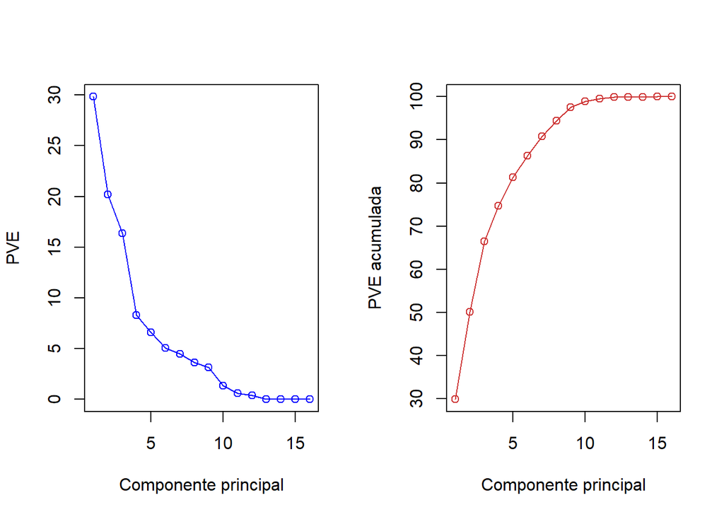

```r
PVE <- 100 * pca_cpes$sdev^2 / sum(pca_cpes$sdev^2)

par(mfrow = c(1,2))
plot(PVE, type = "o",
     ylab = "PVE",
     xlab = "Componente principal",
     col = "blue")
plot(cumsum(PVE), type = "o",
     ylab = "PVE acumulada",
     xlab = "Componente principal",
     col = "brown3")
```

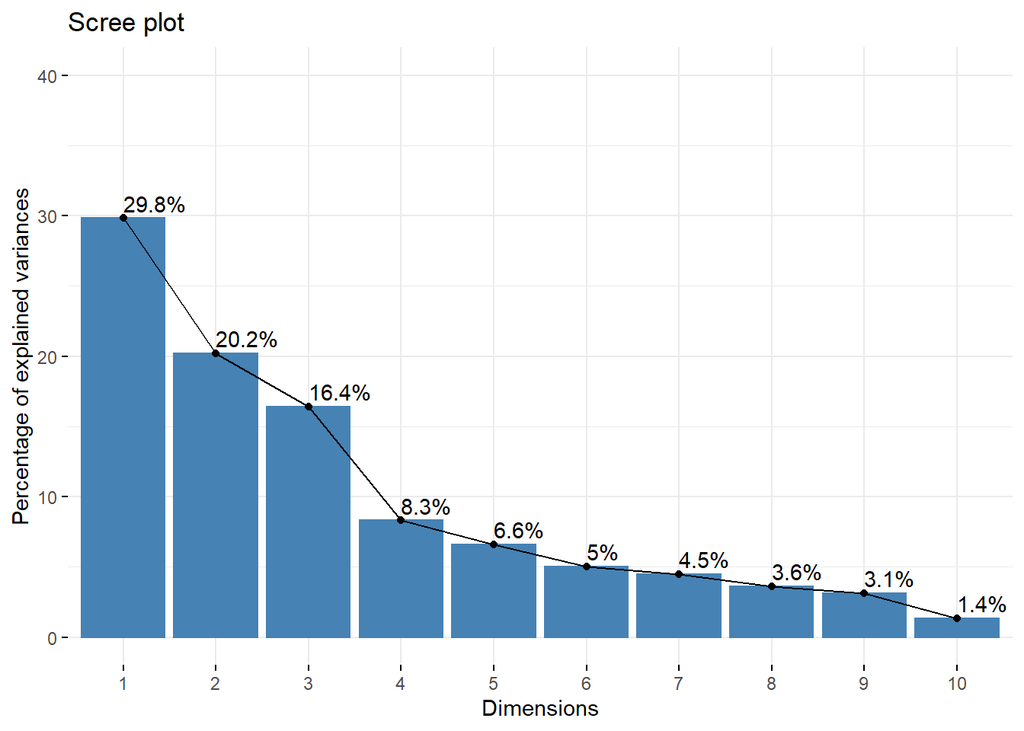

```r
#install.packages("factoextra")
factoextra::fviz_screeplot(pca_cpes, addlabels = TRUE, ylim = c(0, 40))
```

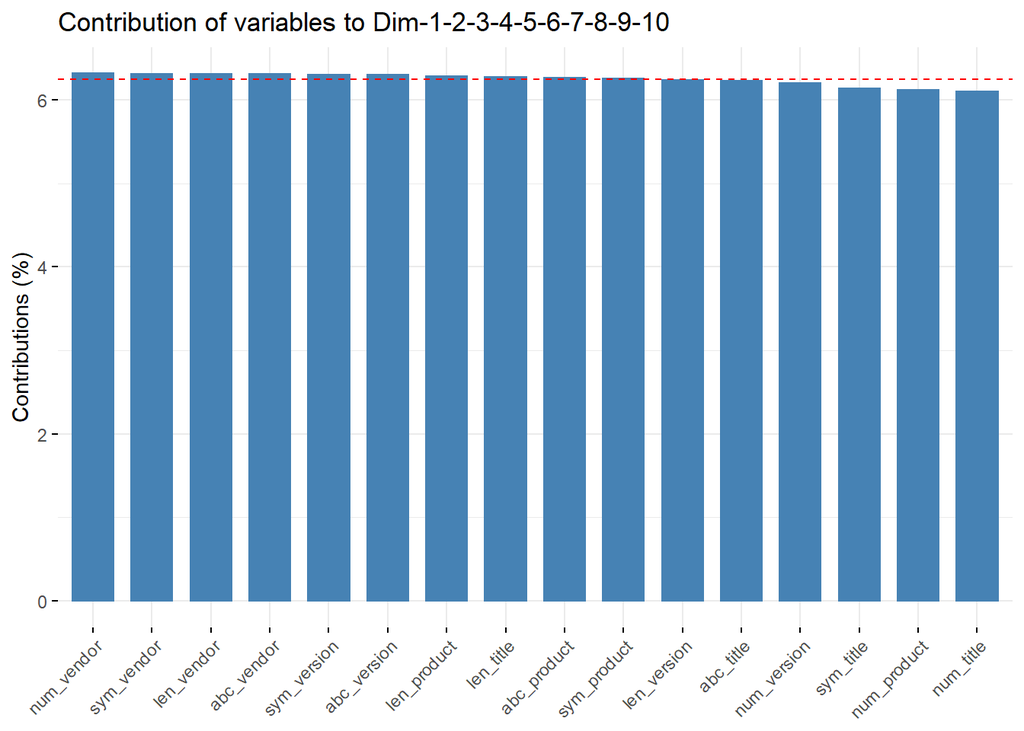

```r
factoextra::fviz_contrib(pca_cpes, choice = "var", axes = 1:10, top = 16)
```

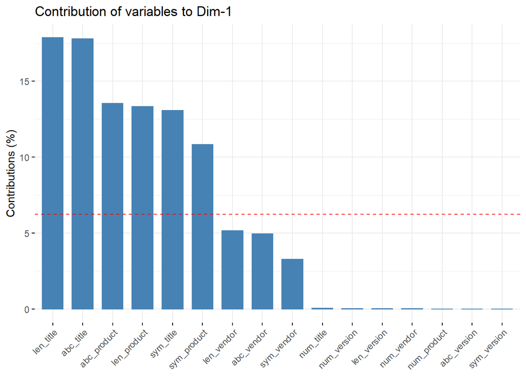

```r
par(mfrow = c(5,2))
factoextra::fviz_contrib(pca_cpes, choice = "var", axes = 1)
```

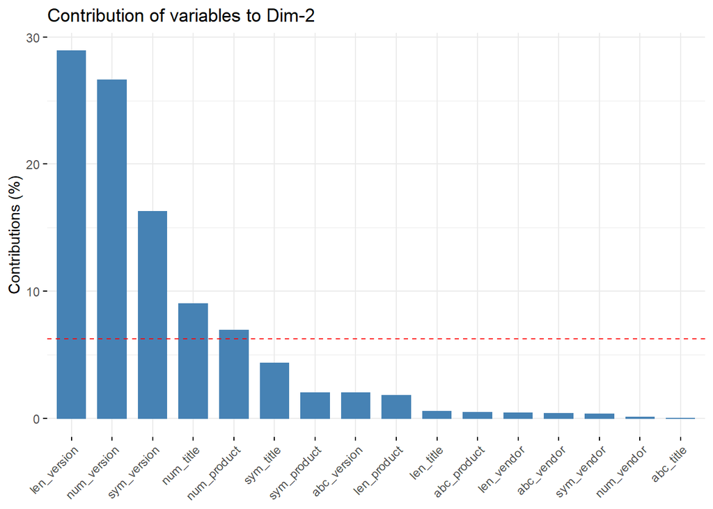

```r
factoextra::fviz_contrib(pca_cpes, choice = "var", axes = 2)
```

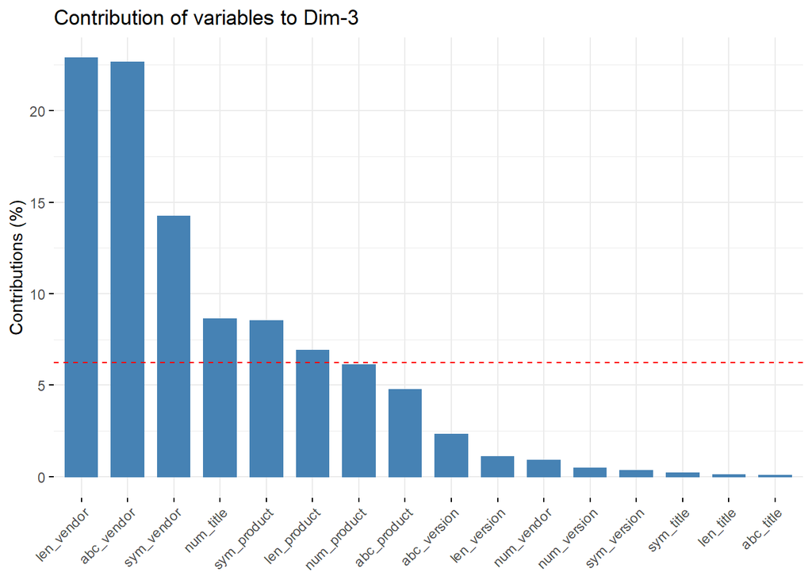

```r
factoextra::fviz_contrib(pca_cpes, choice = "var", axes = 3)
```

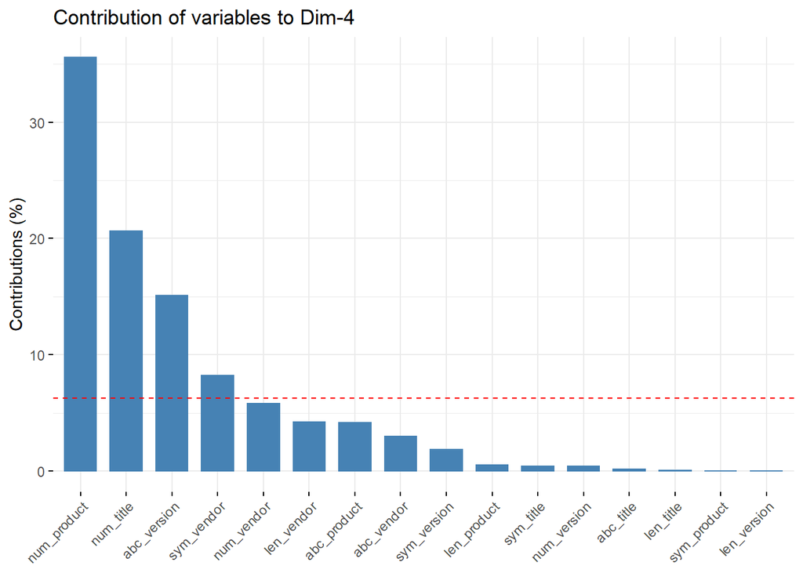

```r
factoextra::fviz_contrib(pca_cpes, choice = "var", axes = 4)
```

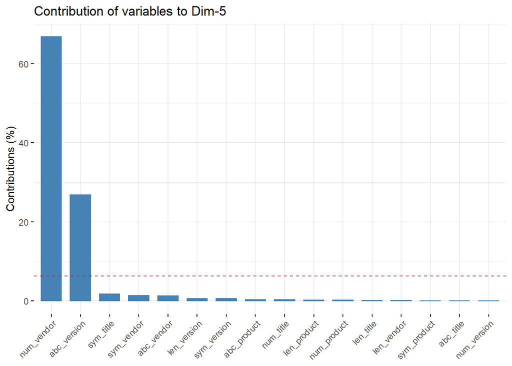

```r
factoextra::fviz_contrib(pca_cpes, choice = "var", axes = 5)
```

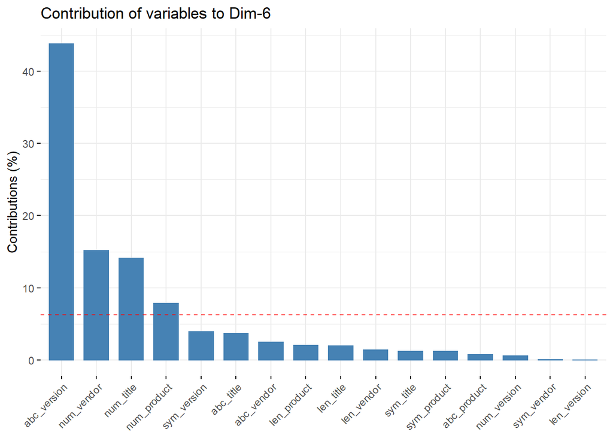

```r
factoextra::fviz_contrib(pca_cpes, choice = "var", axes = 6)
```

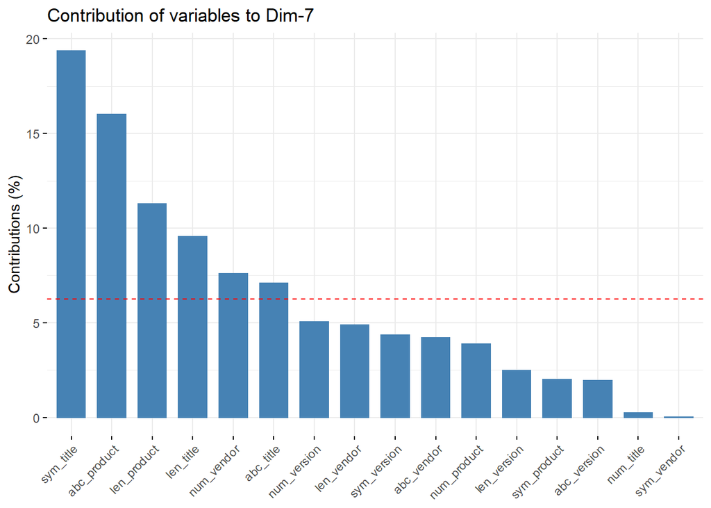

```r
factoextra::fviz_contrib(pca_cpes, choice = "var", axes = 7)
```

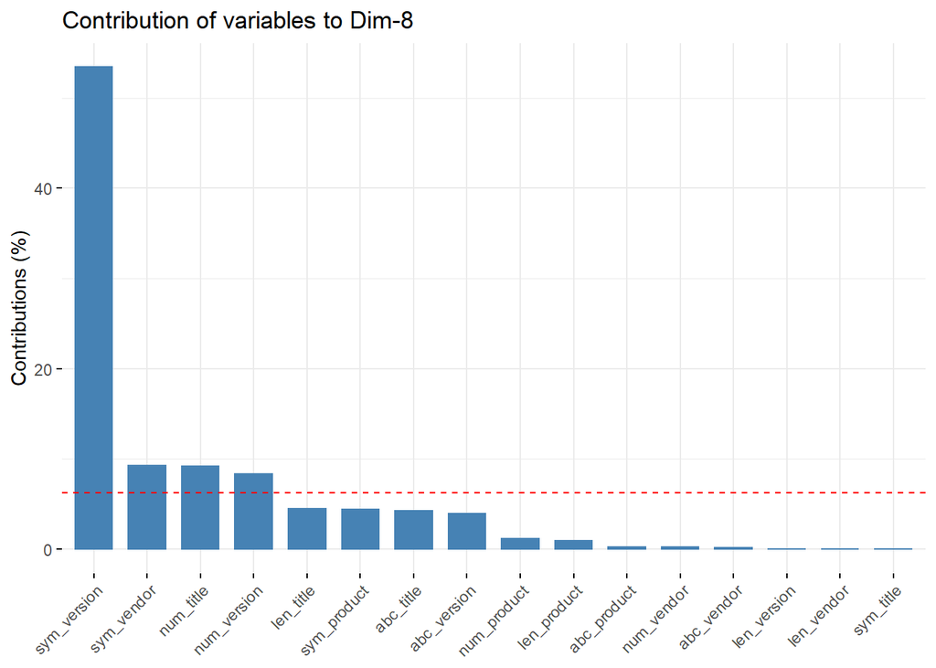

```r
factoextra::fviz_contrib(pca_cpes, choice = "var", axes = 8)
```

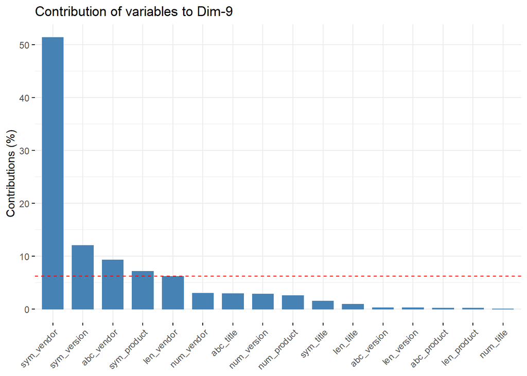

```r
factoextra::fviz_contrib(pca_cpes, choice = "var", axes = 9)
```

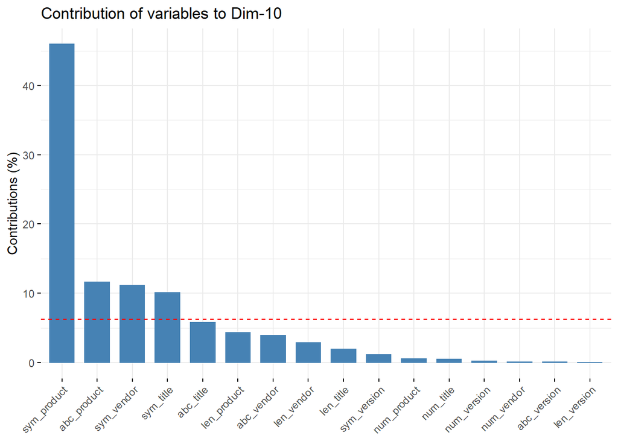

```r
factoextra::fviz_contrib(pca_cpes, choice = "var", axes = 10)
```

```r
# for (i in 1:10) {
#   factoextra::fviz_contrib(pca_cpes, choice = "var", axes = i)
# }
```

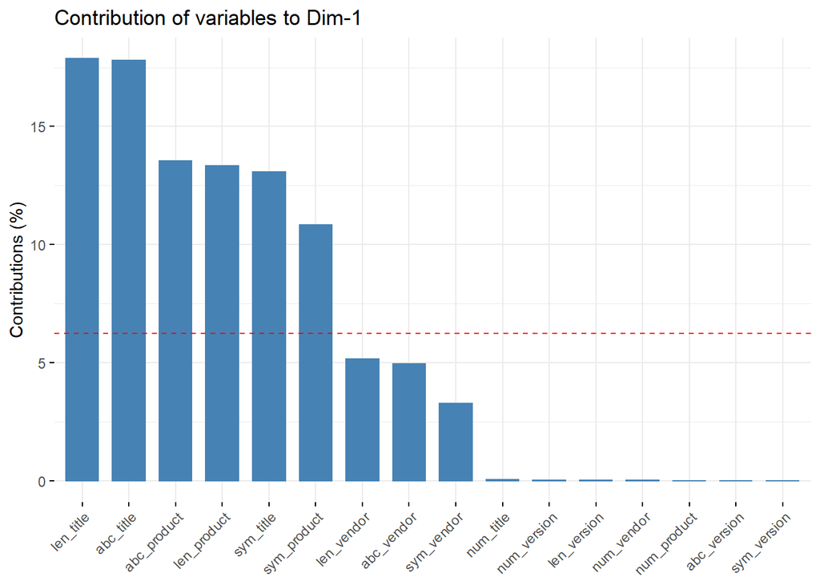

```r
par(mfrow = c(5,2))
factoextra::fviz_contrib(pca_cpes, choice = "var", axes = 1)
```

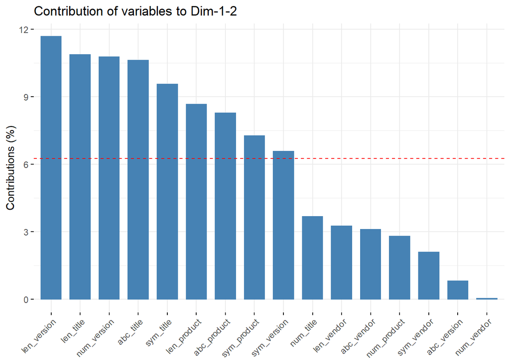

```r
factoextra::fviz_contrib(pca_cpes, choice = "var", axes = 1:2)
```

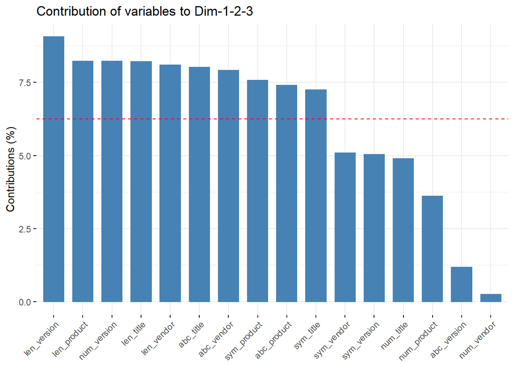

```r
factoextra::fviz_contrib(pca_cpes, choice = "var", axes = 1:3)
```

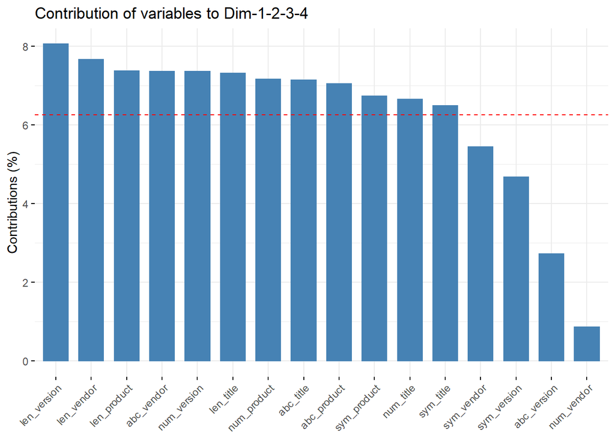

```r
factoextra::fviz_contrib(pca_cpes, choice = "var", axes = 1:4)
```

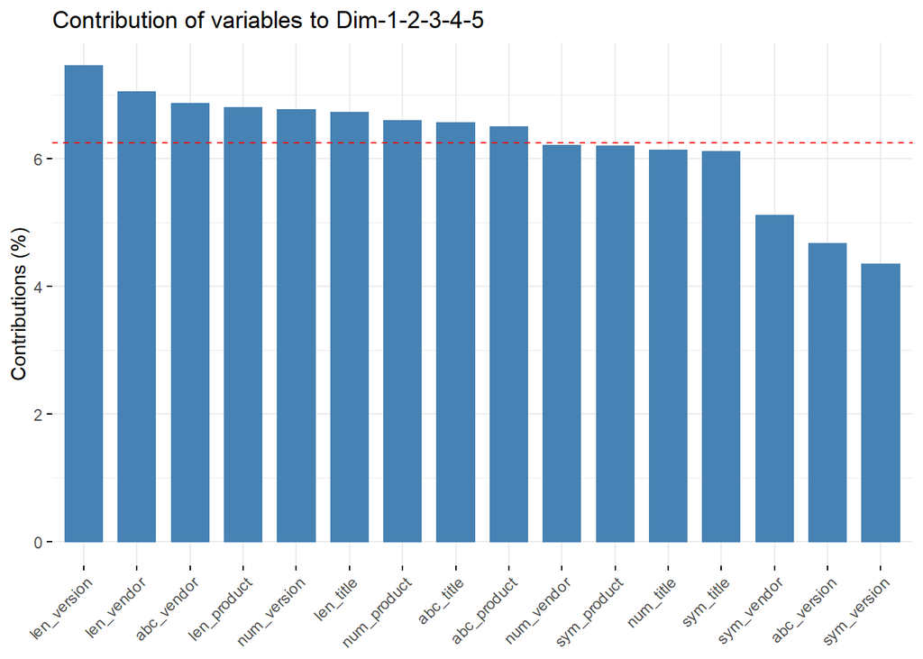

```r
factoextra::fviz_contrib(pca_cpes, choice = "var", axes = 1:5)
```

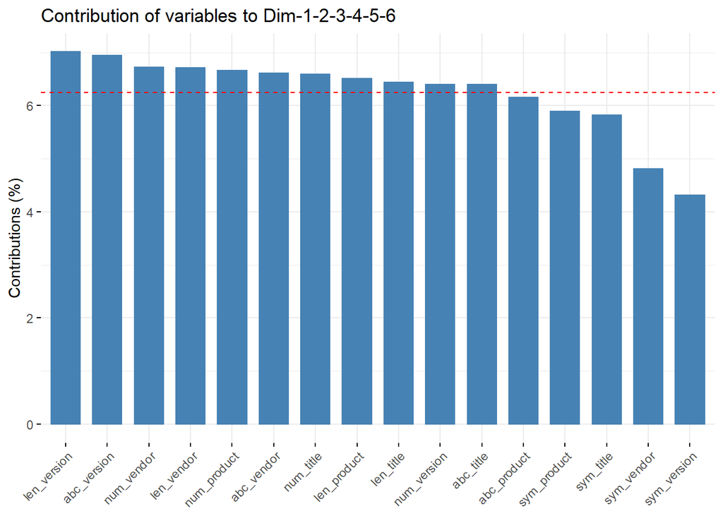

```r
factoextra::fviz_contrib(pca_cpes, choice = "var", axes = 1:6)
```

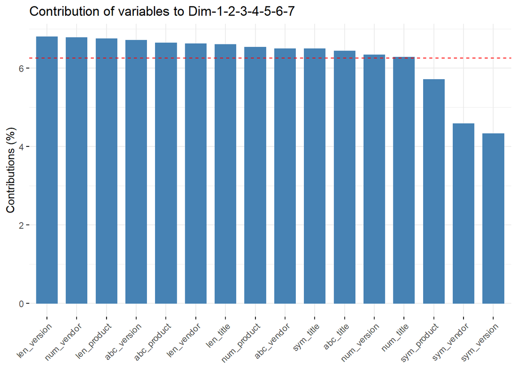

```r
factoextra::fviz_contrib(pca_cpes, choice = "var", axes = 1:7)
```

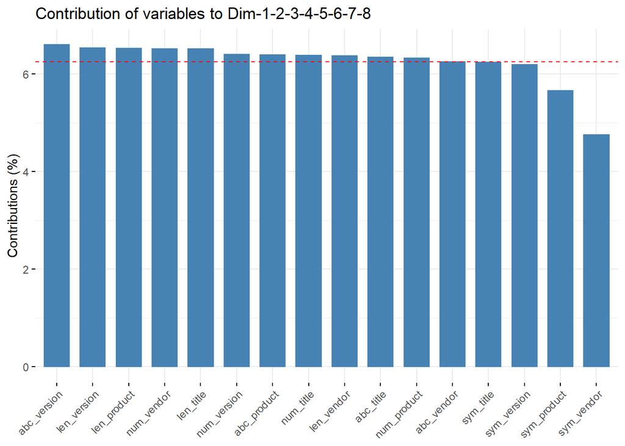

```r
factoextra::fviz_contrib(pca_cpes, choice = "var", axes = 1:8)
```

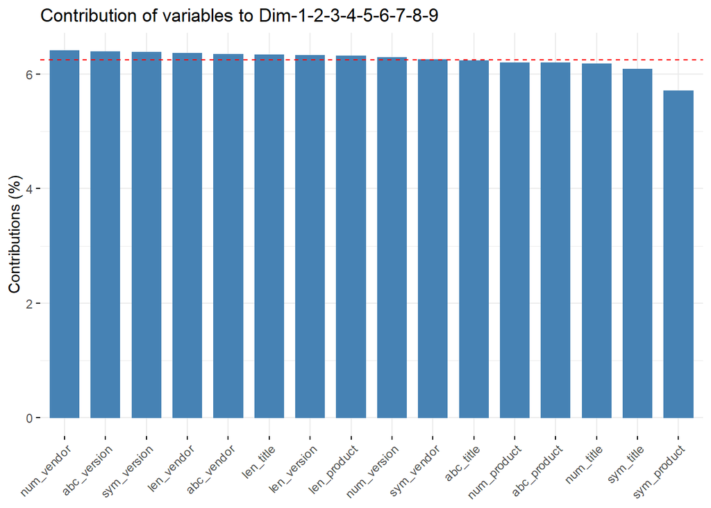

```r
factoextra::fviz_contrib(pca_cpes, choice = "var", axes = 1:9)
```

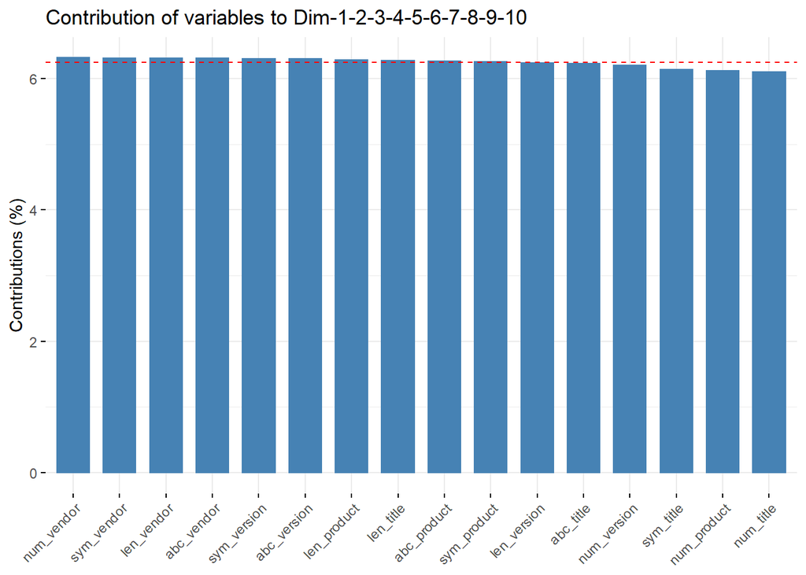

```r
factoextra::fviz_contrib(pca_cpes, choice = "var", axes = 1:10)
```

Let’s check the correlation, maybe we can reduce some features…

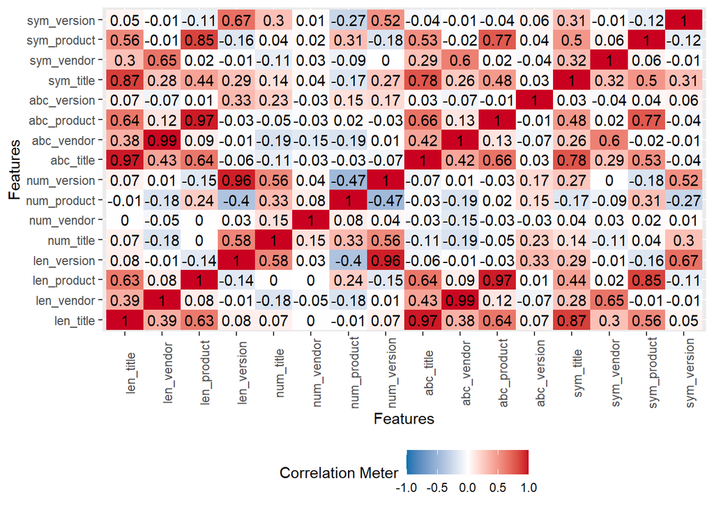

```r
DataExplorer::plot_correlation(dplyr::select(df, -c("title", "part", "vendor", "product", "version")))
```

We can observe high correlation with length and alphabetic. It seems reasonable to keep remove highly correlated features, for example `len_title` and `sym_title`.

Let’s see what happen without them.

```r
pca_lite_cpes <- prcomp(dplyr::select(df, -c("title", "part", "vendor", "product",
                                             "version", "len_title", "sym_title")),
                        scale = T)
summary(pca_lite_cpes)
```

```
## Importance of components:
##                          PC1    PC2    PC3     PC4     PC5     PC6     PC7
## Standard deviation     1.915 1.6972 1.6102 1.15033 1.01956 0.89280 0.75832
## Proportion of Variance 0.262 0.2057 0.1852 0.09452 0.07425 0.05694 0.04107
## Cumulative Proportion  0.262 0.4678 0.6530 0.74749 0.82174 0.87867 0.91975
##                            PC8     PC9    PC10   PC11    PC12    PC13    PC14
## Standard deviation     0.69943 0.58622 0.42936 0.3063 0.08219 0.06679 0.03627
## Proportion of Variance 0.03494 0.02455 0.01317 0.0067 0.00048 0.00032 0.00009
## Cumulative Proportion  0.95469 0.97923 0.99240 0.9991 0.99959 0.99991 1.00000
```

Minor improvement is noticed. The first 7 PCs explain near 92% and top10 more than 99%.

Let’s explore the features…

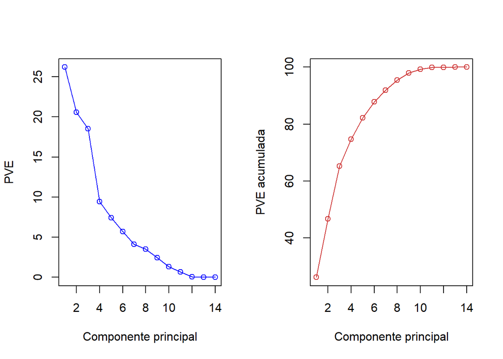

```r
PVE <- 100 * pca_lite_cpes$sdev^2 / sum(pca_lite_cpes$sdev^2)

par(mfrow = c(1,2))
plot(PVE, type = "o",
     ylab = "PVE",
     xlab = "Componente principal",
     col = "blue")
plot(cumsum(PVE), type = "o",
     ylab = "PVE acumulada",
     xlab = "Componente principal",
     col = "brown3")
```

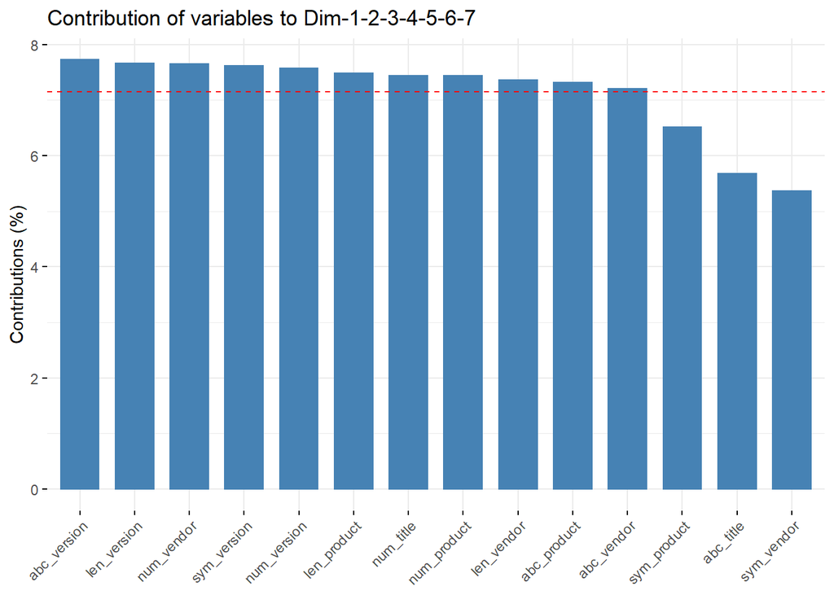

```r
factoextra::fviz_contrib(pca_lite_cpes, choice = "var", axes = 1:7)
```

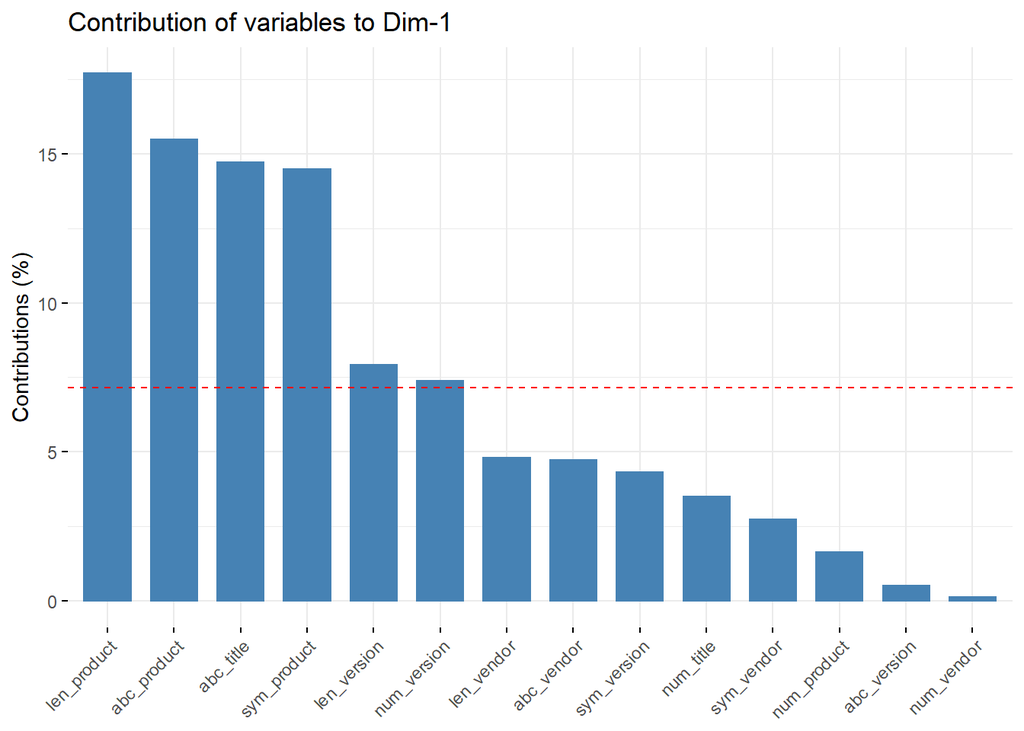

```r
par(mfrow = c(5,2))
factoextra::fviz_contrib(pca_lite_cpes, choice = "var", axes = 1)
```

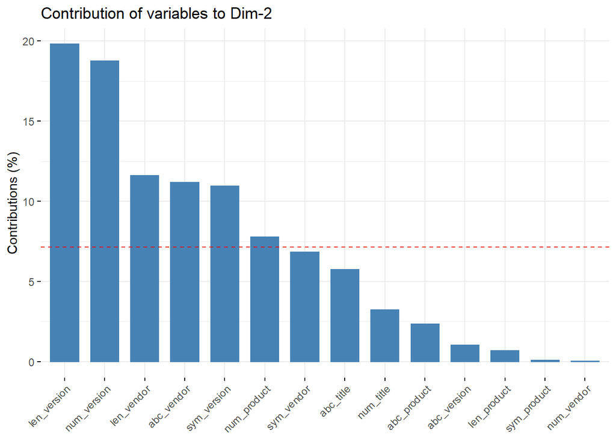

```r
factoextra::fviz_contrib(pca_lite_cpes, choice = "var", axes = 2)
```

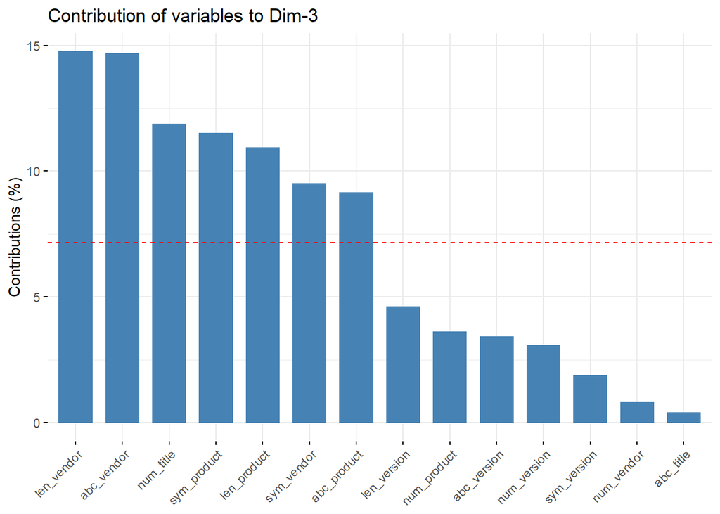

```r
factoextra::fviz_contrib(pca_lite_cpes, choice = "var", axes = 3)
```

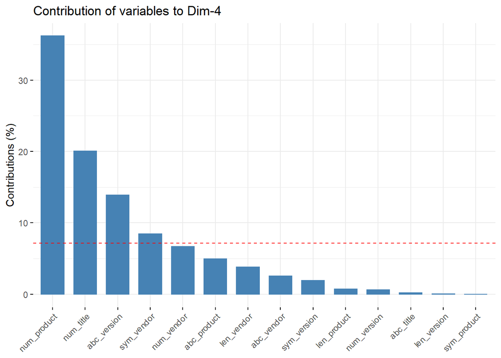

```r
factoextra::fviz_contrib(pca_lite_cpes, choice = "var", axes = 4)
```

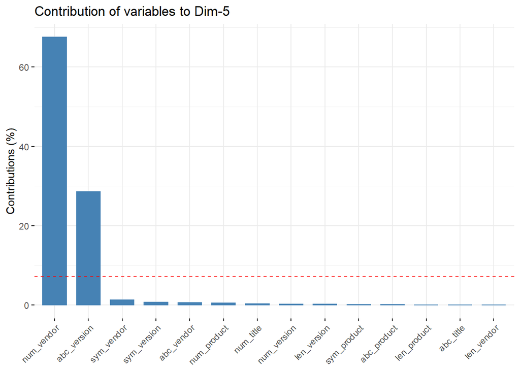

```r
factoextra::fviz_contrib(pca_lite_cpes, choice = "var", axes = 5)
```

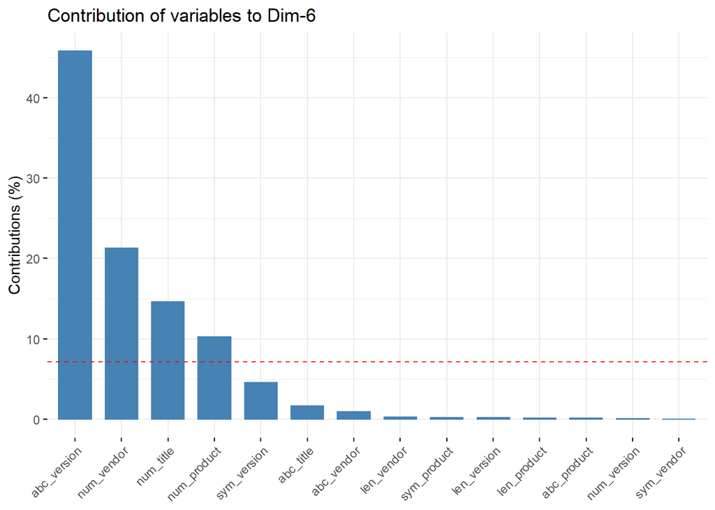

```r
factoextra::fviz_contrib(pca_lite_cpes, choice = "var", axes = 6)
```